# Project 1

Neil Noyes

9/25/2020

## Loading and cleaning the data :: A reflection

The Windows Store data was loaded in using read_csv() with configured columns to reflect the datatypes of each variable. The Price column stood out here, with an automated data type selection of a char (because of the “Free” entry in a lot of prices) and was then configured to be a double. With this change, we developed NA values for the prices of free applications, which then were changed to 0.0. As well as changing the Price variable configuration, I also parsed the Date variable and added columns for year and month for some future analysis dealing with distributions over certain days/years.

## Clean the data with our script

```r
source("CleanData.R", local = knitr::knit_global())
```

```
## here() starts at C:/Users/Neil/Documents/DSCI_301_REPOS/DSCI301-F20-Project1
```

## What does our data show us from the beginning?

This dataset is based on the applications being offered on the Windows Store. The dataset includes the following variables:

- Name (name of the app)
- Rating (rating for the app)
- No of people Rated (count of the total ratings)
- Category (category of application)
- Date (date which the app was posted)
- Price (price of the app)

## Individual Variables

**Rating:** The distribution of ratings for apps on the Windows store:

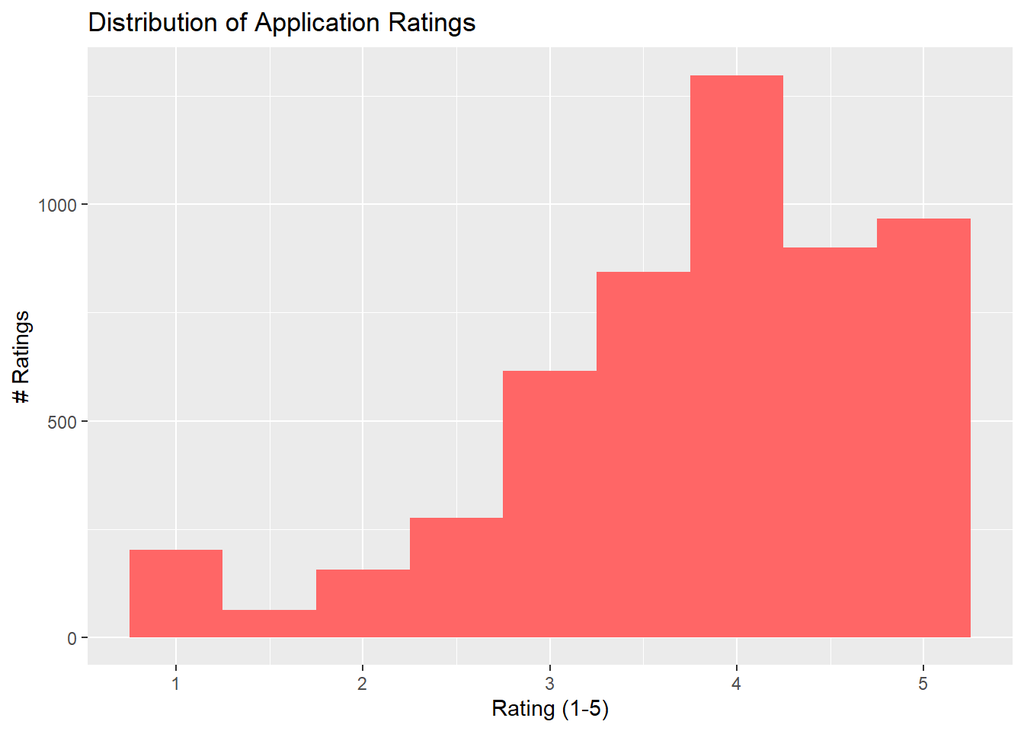

```r
store_data %>%
  ggplot() +
  geom_bar(aes(x = Rating), width = 0.5, fill = "#FF6666") +
  ggtitle("Distribution of Application Ratings") +
  xlab("Rating (1-5)") +
  ylab("# Ratings")
```

While we are at it, lets look at the top 5 apps on the store (relative to how many people rated the application)

```r
topFive <- store_data %>%
  arrange(desc(Rating),desc(`No of people Rated`))%>%
  head(n=5)
  topFive
```

```
## # A tibble: 5 x 8
##   Name          Rating `No of people Ra~ Category   Date       Price  Year Month
##   <chr>          <dbl>             <dbl> <chr>      <date>     <dbl> <dbl> <dbl>
## 1 ILN                5               999 Social     2019-12-05     0  2019    12
## 2 TookBook           5               998 Books      2018-06-26     0  2018     6
## 3 Contemplatio~      5               998 Lifestyle  2018-08-13     0  2018     8
## 4 Five Good Th~      5               996 Lifestyle  2016-10-16     0  2016    10
## 5 Magenta Heal~      5               993 Health an~ 2016-02-28     0  2016     2
```

**Price:** The distribution of application price on the Windows Store:

This table shows that the vast majority of applications are free

```r
store_data %>%
  count(Price <= 0)
```

```
## # A tibble: 2 x 2
##   `Price <= 0`     n
##   <lgl>        <int>
## 1 FALSE          158
## 2 TRUE          5163
```

## Relationships among variables

Let’s took a look at the **number of applications put onto the Window’s Store over time**.

First, we can collect a count for the number of apps on the store each year..

```r
appsPerYear <-
  store_data %>%
    group_by(Year) %>%
    summarise(appCount = n())
    appsPerYear
```

```
## # A tibble: 11 x 2
##     Year appCount
##    <dbl>    <int>
##  1  2010        5
##  2  2011       32
##  3  2012      321
##  4  2013      532
##  5  2014      594
##  6  2015      580
##  7  2016     1013
##  8  2017      794
##  9  2018      796
## 10  2019      468
## 11  2020      186
```

Then we can throw them into ggplot

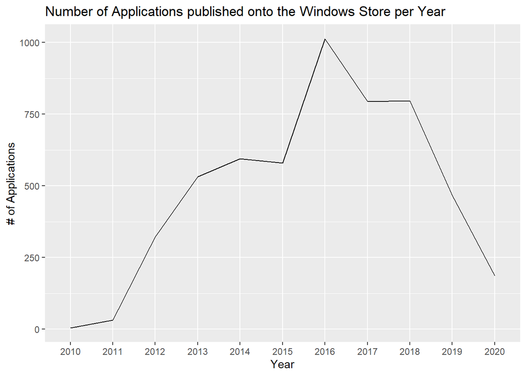

```r
appsPerYear %>%
  ggplot() +
  geom_line(aes(as.factor(Year), appCount, group = 1)) +
  ggtitle("Number of Applications published onto the Windows Store per Year") +
  ylab("# of Applications") +
  xlab("Year")
```

Windows 10 was broadly released for the general public on July 29, 2015 with an *updated version of the Windows Store which merged Microsoft’s other distribution platforms (Windows Marketplace, Windows Phone Store, Xbox Video and Xbox Music) into a unified store front for Windows 10 on all platforms*, offering apps, games, music, film, TV series, themes, and ebooks.This in particular would align with the peek of applications put onto the store the next year (2016) with respect to a couple of hypotheses: 1. Along with the merge, there could’ve been applications previously published elsewhere, but are now counted as released the year of the merge, causing an influx of counts. 2. Since the merge occured, which happened because of Windows 10 release, there could have been potential for a lot of more applications to be published because of the popularity of Windows 10 combined with the ease of applications built for different niche areas (i.e. phone store, Xbox video/music, etc.).

**What categories are rated the highest?**

Let’s get a table going

```r
ratingsPerCategory <-
  store_data %>%
    group_by(Category) %>%
    summarise(avgRating = mean(Rating, na.rm = TRUE))
    ratingsPerCategory
```

```
## # A tibble: 13 x 2
##    Category                avgRating
##    <chr>                       <dbl>
##  1 Books                        3.79
##  2 Business                     3.60
##  3 Developer Tools              3.89
##  4 Food and Dining              3.79
##  5 Government and Politics      4.05
##  6 Health and Fitness           3.79
##  7 Kids and Family              3.95
##  8 Lifestyle                    3.85
##  9 Multimedia Design            3.55
## 10 Music                        3.76
## 11 Navigation and Maps          3.80
## 12 News and Weather             3.84
## 13 Social                       3.85
```

Then

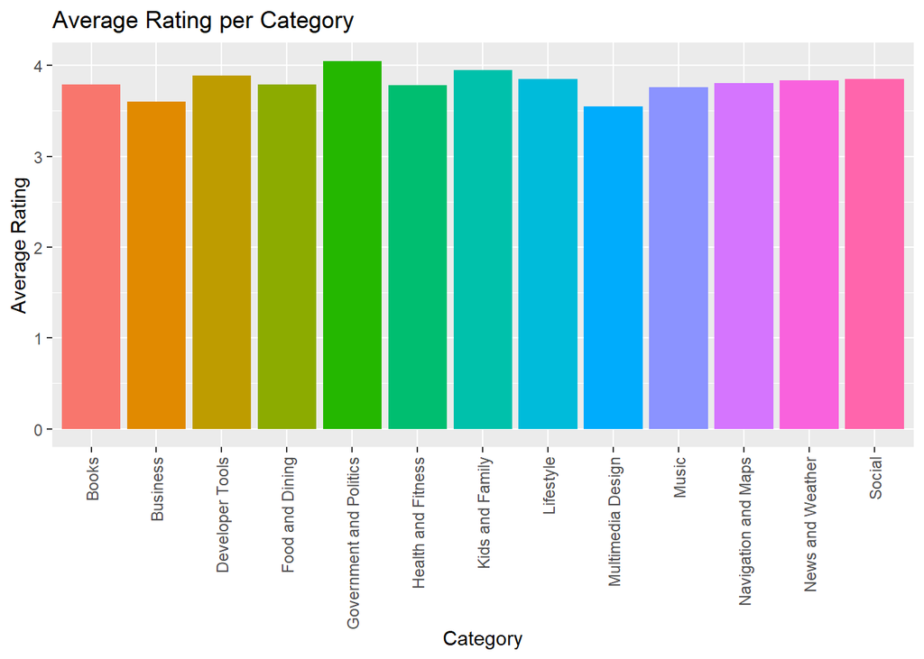

```r
ggplot(ratingsPerCategory, aes(x = Category, y = avgRating, fill = Category)) +
  geom_bar(stat = "identity") +
  theme(axis.text.x = element_text(angle = 90, vjust = 0.5, hjust=1), legend.position = "none") +
  ggtitle("Average Rating per Category") +
  xlab("Category") +
  ylab("Average Rating")
```

## Conclusion

The exploratory data analysis of the Windows Store dataset showed us a few basic, yet interesting details hidden below the surface. Through exploration of single variables, we have shown that there is a high overall rating for applications among the store, accompanied by an overwhelming majority of them being free. We also looked into the relationship between variables by showing the amount of applications released each year over time, which ended up highlighting a major even within the Window’s store’s lifecycle (see Relationships among variables section). We also have an examination of the distribution of average ratings per category of which an application belongs to, which has shown that all of the categories of applications on the Windows store are on average all about the same.

As far as future related works, if it would be possible to gather some further data on the merge of the windows store, I think we could find a good answer to the peek of applications published in 2016, which would be very interesting to dive into. Although there is more possible with the dataset, it is relatively small, so future avenues would primarily involve further and deeper comparison similar to that of what I have already covered. For example, we could look at the busiest time of the year for release dates of applications or even something like average name length. One thing that I think would really tie together this dataset is the amount of downloads that the applciation has, which is very surprising that it isn’t included and could make for some very intersting observations.